# History of dominance hierarchy research - overall publication trends

Liz Hobson (elizabeth.hobson@uc.edu)

# 1 Load packages & functions

```r
library(tidyverse, warn.conflicts=F, quietly=T)
library(gridExtra, warn.conflicts=F, quietly=T)
library(quanteda, warn.conflicts=F, quietly=T)
library(stringr, warn.conflicts=F, quietly=T)
library(scales, warn.conflicts=F, quietly=T)
library(kableExtra, warn.conflicts=F, quietly=T)


# Function to convert to matrix format
matrix.please <- function(x) {
  m<-as.matrix(x[,-1])
  rownames(m)<-x[,1]
  m
}
```

# 2 Import data

```r
d <- read_csv("Data_raw.csv") #head(d)
```

## 2.1 Add decade to data

```r
d$rounded.10yrs <- as.numeric(paste0(substr(d$year, 1, 3), 0))
```

# 3 Overall summary

There are 26146 unique papers in the full dataset. The earliest publication date is 1817. See below for all documents with a publication date prior to 1922.

```r
#view early papers
early.papers <- subset(d, year<1922)

early.papers.K <- early.papers %>%
                    kbl() %>%
                    kable_styling()

scroll_box(
  early.papers.K,
  height = "400px", #width = "500px", height = "200px"
  width = "800px",
  box_css = "border: 1px solid #ddd; padding: 5px; ",
  extra_css = NULL,
  fixed_thead = TRUE
)
```

| rowIDs | year | source | authors | title | n.citations | ECC | rounded.10yrs |
| --- | --- | --- | --- | --- | --- | --- | --- |
| 2 | 1817 | researchgate.net | MH Gallardo | Superfamily Cavioidea G. Fischer, 1817 | 0 | 0 | 1810 |
| 4 | 1865 | NA | B INSTIUTE | STEVE RAYNER | 0 | 0 | 1860 |
| 5 | 1886 | NA | AW Besant | The Evolution of Society | 8 | 8 | 1880 |
| 6 | 1899 | NA | H Jones | Social and Individual Evolution | 0 | 0 | 1890 |
| 7 | 1905 | NA | WF Hadley | Aggressive Behavior and Social Hierarchy in the Pinfish, Lagodon Rhomboides (Linnaeus) | 0 | 0 | 1900 |
| 8 | 1917 | NA | BA MBiolSci | The causes and consequences of individual variation in cognitive ability in the cooperatively breeding Australian magpie (Cracticus tibicen dorsalis) | 0 | 0 | 1910 |
| 9 | 1919 | NA | EJ McCarey | PRACTICAL TOOLS FOR YOUR MORAL TOOLKIT: A LEADERSHIP GUIDE TO GROUP ETHICAL BEHAVIOR | 0 | 0 | 1910 |

## 3.1 Subset to consider just papers after 1922

Because we are concerned with papers published after the foundational dominance hierarchy paper (published in 1922), I included only documents with publication dates later than 1922. I also checked to make sure all documents had publication year data (no records returned = none missing year). I also checked that none were missing their titles.

```r
#subset data to just after 1922
d.post1922 <- subset(d, year>1922)

#check that none of the years are missing
subset(d.post1922, is.na(year))
```

| rowIDs | year | source | authors | title | n.citations | ECC | rounded.10yrs |
| --- | --- | --- | --- | --- | --- | --- | --- |

```r
#check that none of the titles are missing
subset(d.post1922, is.na(title))
```

| rowIDs | year | source | authors | title | n.citations | ECC | rounded.10yrs |
| --- | --- | --- | --- | --- | --- | --- | --- |

```r
# Summaries
# Number unique paper titles after 1922 #length(unique(d.post1922$title))

#First publication year after 1922 #min(d.post1922$year, na.rm=TRUE)
```

# 4 Summarize annual publication amounts

## 4.1 Use compiled citation data to summarize and plot papers by year and citations to those papers by publication date.

```r
d.post1922_summXyear <- d.post1922 %>% group_by(year) %>% summarize(n.papersXyear=n(),
                                                                  n.citestopaperXpubyr=sum(ECC),
                                                                  n.citestopaperXpubyr_max=max(ECC),
                                                                  n.citestopaperXpubyr_median=median(ECC))

d.post1922_summXyear.K <- d.post1922_summXyear %>%
                            kbl() %>%
                            kable_styling()

#view
scroll_box(
  d.post1922_summXyear.K,
  height = "400px", #width = "500px", height = "200px"
  width = "800px",
  box_css = "border: 1px solid #ddd; padding: 5px; ",
  extra_css = NULL,
  fixed_thead = TRUE
)
```

| year | n.papersXyear | n.citestopaperXpubyr | n.citestopaperXpubyr_max | n.citestopaperXpubyr_median |
| --- | --- | --- | --- | --- |
| 1925 | 1 | 0 | 0 | 0.0 |
| 1928 | 1 | 0 | 0 | 0.0 |
| 1933 | 1 | 0 | 0 | 0.0 |
| 1934 | 1 | 55 | 55 | 55.0 |
| 1935 | 2 | 98 | 82 | 49.0 |
| 1936 | 2 | 262 | 171 | 131.0 |
| 1937 | 2 | 34 | 22 | 17.0 |
| 1938 | 2 | 323 | 241 | 161.5 |
| 1939 | 2 | 91 | 80 | 45.5 |
| 1940 | 1 | 53 | 53 | 53.0 |
| 1941 | 1 | 27 | 27 | 27.0 |
| 1942 | 2 | 81 | 55 | 40.5 |
| 1943 | 3 | 63 | 58 | 5.0 |
| 1944 | 3 | 417 | 372 | 33.0 |
| 1945 | 2 | 224 | 180 | 112.0 |
| 1946 | 3 | 226 | 144 | 73.0 |
| 1947 | 3 | 522 | 460 | 62.0 |
| 1948 | 2 | 253 | 253 | 126.5 |
| 1950 | 5 | 30 | 24 | 2.0 |
| 1951 | 8 | 834 | 540 | 29.0 |
| 1952 | 6 | 827 | 620 | 50.0 |
| 1953 | 5 | 330 | 311 | 3.0 |
| 1954 | 9 | 1004 | 422 | 19.0 |
| 1955 | 9 | 499 | 267 | 17.0 |
| 1956 | 12 | 1090 | 651 | 29.0 |
| 1957 | 9 | 308 | 88 | 29.0 |
| 1958 | 7 | 892 | 393 | 49.0 |
| 1959 | 12 | 581 | 274 | 12.0 |
| 1960 | 19 | 1049 | 240 | 22.0 |
| 1961 | 17 | 5567 | 3985 | 34.0 |

[output cut: 59 more lines]

### 4.1.1 Summary of publications per year

There are 25219 unique documents published after 1922 in the database. The earliest year of publication in the dataset is now 1925.

The year with the most publications was 2017 which had a total of 952. The mean number of papers per year was 285.43 and the median number of papers per year was 166.

## 4.2 Use compiled citation data to summarize papers by decade

```r
d.post1922_summXdecade <- d.post1922 %>% group_by(rounded.10yrs) %>% summarize(n.papersXdecade=n(),
                                                                  n.citestopaperXpubyr=sum(ECC),
                                                                  n.citestopaperXpubyr_max=max(ECC),
                                                                  n.citestopaperXpubyr_median=median(ECC))

d.post1922_summXdecade.K <- d.post1922_summXdecade %>%
                            kbl() %>%
                            kable_styling()

#view
scroll_box(
  d.post1922_summXdecade.K,
  height = "400px", #width = "500px", height = "200px"
  width = "800px",
  box_css = "border: 1px solid #ddd; padding: 5px; ",
  extra_css = NULL,
  fixed_thead = TRUE
)
```

| rounded.10yrs | n.papersXdecade | n.citestopaperXpubyr | n.citestopaperXpubyr_max | n.citestopaperXpubyr_median |
| --- | --- | --- | --- | --- |
| 1920 | 2 | 0 | 0 | 0.0 |
| 1930 | 12 | 863 | 241 | 67.5 |
| 1940 | 20 | 1866 | 460 | 48.5 |
| 1950 | 82 | 6395 | 651 | 19.5 |
| 1960 | 329 | 36878 | 6701 | 21.0 |
| 1970 | 1434 | 113055 | 8068 | 26.0 |
| 1980 | 2559 | 177032 | 4416 | 25.0 |
| 1990 | 3722 | 329511 | 16093 | 27.0 |
| 2000 | 6951 | 582907 | 33372 | 20.0 |
| 2010 | 9386 | 267766 | 21857 | 6.0 |
| 2020 | 906 | 2654 | 380 | 1.0 |

## 4.3 Add normalization to decadal summaries (+/- last decade’s counts)

Use lag( ) to compare each decade’s number of publications to the number published in the previous decade. Find the difference in the numbers of papers (where positive = more papers published in one decade compared to the last and negative = publication numbers have decreased compared to previous decade). Find the percent growth rate for both the number of publications by decade and also citations to those papers by publication decade.

```r
d.post1922_summXdecade$lag.npapers <- lag(d.post1922_summXdecade$n.papersXdecade)
d.post1922_summXdecade$lag.ncitesXpubyr <- lag(d.post1922_summXdecade$n.citestopaperXpubyr)

d.post1922_summXdecade$diff.npapers <- d.post1922_summXdecade$n.papersXdecade - d.post1922_summXdecade$lag.npapers
d.post1922_summXdecade$diff.ncitesXpubyr <- d.post1922_summXdecade$n.citestopaperXpubyr - d.post1922_summXdecade$lag.ncitesXpubyr

d.post1922_summXdecade$DoD.npaper.growth <- (d.post1922_summXdecade$diff.npapers/d.post1922_summXdecade$lag.npapers) *100
d.post1922_summXdecade$DoD.ncitesXpubyr.growth <- (d.post1922_summXdecade$diff.ncitesXpubyr/d.post1922_summXdecade$lag.ncitesXpubyr) *100

#view
#d.post1922_summXdecade

d.post1922_summXdecade.K <- d.post1922_summXdecade %>%
                            kbl() %>%
                            kable_styling()

#view
scroll_box(
  d.post1922_summXdecade.K,
  height = "400px", #width = "500px", height = "200px"
  width = "800px",
  box_css = "border: 1px solid #ddd; padding: 5px; ",
  extra_css = NULL,
  fixed_thead = TRUE
)
```

| rounded.10yrs | n.papersXdecade | n.citestopaperXpubyr | n.citestopaperXpubyr_max | n.citestopaperXpubyr_median | lag.npapers | lag.ncitesXpubyr | diff.npapers | diff.ncitesXpubyr | DoD.npaper.growth | DoD.ncitesXpubyr.growth |
| --- | --- | --- | --- | --- | --- | --- | --- | --- | --- | --- |
| 1920 | 2 | 0 | 0 | 0.0 | NA | NA | NA | NA | NA | NA |
| 1930 | 12 | 863 | 241 | 67.5 | 2 | 0 | 10 | 863 | 500.00000 | Inf |
| 1940 | 20 | 1866 | 460 | 48.5 | 12 | 863 | 8 | 1003 | 66.66667 | 116.22248 |
| 1950 | 82 | 6395 | 651 | 19.5 | 20 | 1866 | 62 | 4529 | 310.00000 | 242.71168 |
| 1960 | 329 | 36878 | 6701 | 21.0 | 82 | 6395 | 247 | 30483 | 301.21951 | 476.66927 |
| 1970 | 1434 | 113055 | 8068 | 26.0 | 329 | 36878 | 1105 | 76177 | 335.86626 | 206.56489 |
| 1980 | 2559 | 177032 | 4416 | 25.0 | 1434 | 113055 | 1125 | 63977 | 78.45188 | 56.58927 |
| 1990 | 3722 | 329511 | 16093 | 27.0 | 2559 | 177032 | 1163 | 152479 | 45.44744 | 86.13076 |
| 2000 | 6951 | 582907 | 33372 | 20.0 | 3722 | 329511 | 3229 | 253396 | 86.75443 | 76.90062 |
| 2010 | 9386 | 267766 | 21857 | 6.0 | 6951 | 582907 | 2435 | -315141 | 35.03093 | -54.06368 |
| 2020 | 906 | 2654 | 380 | 1.0 | 9386 | 267766 | -8480 | -265112 | -90.34733 | -99.00884 |

## 4.4 Number of papers published by decade

Compared to the previous decade, how many more papers have been published? This approach helps to control for changes in overall publication patterns, so we are not comparing publication numbers in 2010s to those in 1930s for example. I removed papers published in the 2020s because we don’t have enough data yet for it to make sense to compare to 2010s.

```r
#remove 2020s publication dates
d.post1922_summXdecade.no2020 <- subset(d.post1922_summXdecade, rounded.10yrs!="2020")

d.post1922_summXdecade.no2020.K <- d.post1922_summXdecade.no2020 %>%
                            kbl() %>%
                            kable_styling()

#view
scroll_box(
  d.post1922_summXdecade.no2020.K,
  height = "400px", #width = "500px", height = "200px"
  width = "800px",
  box_css = "border: 1px solid #ddd; padding: 5px; ",
  extra_css = NULL,
  fixed_thead = TRUE
)
```

| rounded.10yrs | n.papersXdecade | n.citestopaperXpubyr | n.citestopaperXpubyr_max | n.citestopaperXpubyr_median | lag.npapers | lag.ncitesXpubyr | diff.npapers | diff.ncitesXpubyr | DoD.npaper.growth | DoD.ncitesXpubyr.growth |
| --- | --- | --- | --- | --- | --- | --- | --- | --- | --- | --- |
| 1920 | 2 | 0 | 0 | 0.0 | NA | NA | NA | NA | NA | NA |
| 1930 | 12 | 863 | 241 | 67.5 | 2 | 0 | 10 | 863 | 500.00000 | Inf |
| 1940 | 20 | 1866 | 460 | 48.5 | 12 | 863 | 8 | 1003 | 66.66667 | 116.22248 |
| 1950 | 82 | 6395 | 651 | 19.5 | 20 | 1866 | 62 | 4529 | 310.00000 | 242.71168 |
| 1960 | 329 | 36878 | 6701 | 21.0 | 82 | 6395 | 247 | 30483 | 301.21951 | 476.66927 |
| 1970 | 1434 | 113055 | 8068 | 26.0 | 329 | 36878 | 1105 | 76177 | 335.86626 | 206.56489 |
| 1980 | 2559 | 177032 | 4416 | 25.0 | 1434 | 113055 | 1125 | 63977 | 78.45188 | 56.58927 |
| 1990 | 3722 | 329511 | 16093 | 27.0 | 2559 | 177032 | 1163 | 152479 | 45.44744 | 86.13076 |
| 2000 | 6951 | 582907 | 33372 | 20.0 | 3722 | 329511 | 3229 | 253396 | 86.75443 | 76.90062 |
| 2010 | 9386 | 267766 | 21857 | 6.0 | 6951 | 582907 | 2435 | -315141 | 35.03093 | -54.06368 |

### 4.4.1 View simplified dataframe of decadal publication data with data from plots

This dataframe shows the number of papers published by decade (n.papersXdecade), the difference in the number of papers published in each decade compared to the previous decade (diff.npapers), and the decade over decade percent growth in the number of papers published (DoD.npaper.growth).

```r
d.post1922_summXdecade.no2020.tr <- subset(d.post1922_summXdecade.no2020, select=c(rounded.10yrs, n.papersXdecade, diff.npapers, DoD.npaper.growth))

d.post1922_summXdecade.no2020.tr.K <- d.post1922_summXdecade.no2020.tr %>%
                            kbl() %>%
                            kable_styling()

#view
scroll_box(
  d.post1922_summXdecade.no2020.tr.K,
  height = "400px", #width = "500px", height = "200px"
  width = "800px",
  box_css = "border: 1px solid #ddd; padding: 5px; ",
  extra_css = NULL,
  fixed_thead = TRUE
)
```

| rounded.10yrs | n.papersXdecade | diff.npapers | DoD.npaper.growth |
| --- | --- | --- | --- |
| 1920 | 2 | NA | NA |
| 1930 | 12 | 10 | 500.00000 |
| 1940 | 20 | 8 | 66.66667 |
| 1950 | 82 | 62 | 310.00000 |
| 1960 | 329 | 247 | 301.21951 |
| 1970 | 1434 | 1105 | 335.86626 |
| 1980 | 2559 | 1125 | 78.45188 |
| 1990 | 3722 | 1163 | 45.44744 |
| 2000 | 6951 | 3229 | 86.75443 |
| 2010 | 9386 | 2435 | 35.03093 |

### 4.4.2 Plot number of papers published by decade

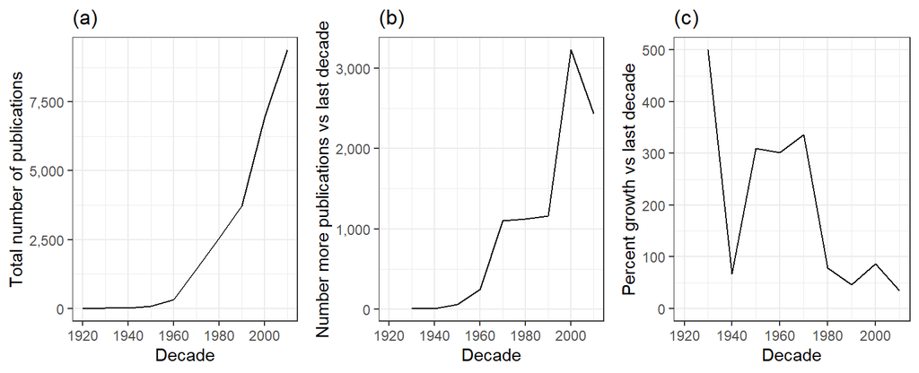

```r
npapersXdecade <- ggplot(d.post1922_summXdecade.no2020, aes(x=rounded.10yrs, y=n.papersXdecade)) +
  geom_line() +
  labs(x="Decade", y="Total number of publications", title="(a)") +
  scale_y_continuous(labels = scales::comma) +
  theme_bw()

npapersXdecade.compare <- ggplot(d.post1922_summXdecade.no2020, aes(x=rounded.10yrs, y=diff.npapers)) +
  geom_line() +
  labs(x="Decade", y="Number more publications vs last decade", title="(b)") +
  scale_y_continuous(labels = scales::comma) +
  theme_bw()

npapersDoD.growth <- ggplot(d.post1922_summXdecade.no2020, aes(x=rounded.10yrs, y=DoD.npaper.growth)) +
  geom_line() +
  labs(x="Decade", y="Percent growth vs last decade", title="(c)") +
  ylim(0,max(d.post1922_summXdecade.no2020$DoD.npaper.growth)) +
  theme_bw()


#print plot
grid.arrange(npapersXdecade, npapersXdecade.compare, npapersDoD.growth, ncol = 3, nrow = 1)
```

```r
#save plot as pdf
  #pdf("Fig1_publicationrates.pdf", width=8, height=3.25)
  #grid.arrange(npapersXdecade, npapersXdecade.compare, npapersDoD.growth, ncol = 3, nrow = 1)
  #dev.off()
```

```r
citation("tidyverse")
```

```
##
##   Wickham et al., (2019). Welcome to the tidyverse. Journal of Open
##   Source Software, 4(43), 1686, https://doi.org/10.21105/joss.01686
##
## A BibTeX entry for LaTeX users is
##
##   @Article{,
##     title = {Welcome to the {tidyverse}},
##     author = {Hadley Wickham and Mara Averick and Jennifer Bryan and Winston Chang and Lucy D'Agostino McGowan and Romain François and Garrett Grolemund and Alex Hayes and Lionel Henry and Jim Hester and Max Kuhn and Thomas Lin Pedersen and Evan Miller and Stephan Milton Bache and Kirill Müller a…
##     year = {2019},
##     journal = {Journal of Open Source Software},
##     volume = {4},
##     number = {43},
##     pages = {1686},
##     doi = {10.21105/joss.01686},
##   }
```

```r
citation("gridExtra")
```

```
##
##
##   Baptiste Auguie (2017). gridExtra: Miscellaneous Functions for "Grid"
##   Graphics. R package version 2.3.
##   https://CRAN.R-project.org/package=gridExtra
##
## A BibTeX entry for LaTeX users is
##
##   @Manual{,
##     title = {gridExtra: Miscellaneous Functions for "Grid" Graphics},
##     author = {Baptiste Auguie},
##     year = {2017},
##     note = {R package version 2.3},
##     url = {https://CRAN.R-project.org/package=gridExtra},
##   }
```

```r
citation("quanteda")
```

```
##
## Benoit K, Watanabe K, Wang H, Nulty P, Obeng A, Müller S, Matsuo A
## (2018). "quanteda: An R package for the quantitative analysis of
## textual data." _Journal of Open Source Software_, *3*(30), 774. doi:
## 10.21105/joss.00774 (URL: https://doi.org/10.21105/joss.00774), <URL:
## https://quanteda.io>.
##
## A BibTeX entry for LaTeX users is
##
##   @Article{,
##     title = {quanteda: An R package for the quantitative analysis of textual data},
##     journal = {Journal of Open Source Software},
##     author = {Kenneth Benoit and Kohei Watanabe and Haiyan Wang and Paul Nulty and Adam Obeng and Stefan Müller and Akitaka Matsuo},
##     doi = {10.21105/joss.00774},
##     url = {https://quanteda.io},
##     volume = {3},
##     number = {30},
##     pages = {774},
##     year = {2018},
##   }
```

```r
citation("stringr")
```

```
##
##
##   Hadley Wickham (2019). stringr: Simple, Consistent Wrappers for
##   Common String Operations. R package version 1.4.0.
##   https://CRAN.R-project.org/package=stringr
##
## A BibTeX entry for LaTeX users is
##
##   @Manual{,
##     title = {stringr: Simple, Consistent Wrappers for Common String Operations},
##     author = {Hadley Wickham},
##     year = {2019},
##     note = {R package version 1.4.0},
##     url = {https://CRAN.R-project.org/package=stringr},
##   }
```

```r
citation("scales")
```

```
##
##
##   Hadley Wickham and Dana Seidel (2019). scales: Scale Functions for
##   Visualization. R package version 1.1.0.
##   https://CRAN.R-project.org/package=scales
##
## A BibTeX entry for LaTeX users is
##
##   @Manual{,
##     title = {scales: Scale Functions for Visualization},
##     author = {Hadley Wickham and Dana Seidel},
##     year = {2019},
##     note = {R package version 1.1.0},
##     url = {https://CRAN.R-project.org/package=scales},
##   }
```

```r
citation("kableExtra")
```

```
##
##
##   Hao Zhu (2020). kableExtra: Construct Complex Table with 'kable' and
##   Pipe Syntax. R package version 1.2.1.
##   https://CRAN.R-project.org/package=kableExtra
##
## A BibTeX entry for LaTeX users is
##
##   @Manual{,
##     title = {kableExtra: Construct Complex Table with 'kable' and Pipe Syntax},
##     author = {Hao Zhu},
##     year = {2020},
##     note = {R package version 1.2.1},
##     url = {https://CRAN.R-project.org/package=kableExtra},
##   }
```